# SARS-CoV-2 Bottleneck Preliminary Analysis

Will Hannon

8/13/2020

## Notebook Overview

#### Project Aim

This analysis aims to see if there is a substantial transmission of intra-host minor variants between individuals in a large cluster of infections. This information could help characterize the inter-host transmission bottleneck in SARS-CoV-2 with the highest resolution achieved so far.

#### Cohort Overview

There was an outbreak on a fishing boat in Seattle. Individuals (120/122) were screened for SARS-CoV-2 RNA by RT-qPCR and seroconversion by the Abbot IgG assay both before departure and after return. Although all were negative, an outbreak occured nonetheless. A total of 104/122 crew members had viral RNA or seroconverted upon return to shore (84% Attack Rate).

#### Data Overview

From the 104 reportedly infected crew memebers there are 39 metagenomic RNA-sequencing runs avaliable. The data is avaliable publically at NCBI BioProject [`PRJNA610428`](https://www.ncbi.nlm.nih.gov/Traces/study/?query_key=2&WebEnv=MCID_5f344f743a76fab9ab22e42b&o=acc_s%3Aa). Metadata for the identity of samples is avaliable in Supplementary Table 2.

The metadata only contains the GISAID-ID for the consensus and the strain. I might be able to use the strain to figure out the SRR# using the metadata on the SRA run selector.

#### Experimental Overview

Libraries were sequenced on a 1x75 bp Illumina NextSeq run. A median of 509,551 sequencing reads were obtained for each sample.

#### Included Samples

The paper has a supplementary table (Supplementary Table 2.) that includes the strain names for each individual and the GISAID ID for the consensus, but not the SRA accession. I used this information to search the Bioproject ([`PRJNA610428`](https://www.ncbi.nlm.nih.gov/Traces/study/?query_key=2&WebEnv=MCID_5f344f743a76fab9ab22e42b&o=acc_s%3Aa)) for the relevant samples. This Bioproject contains all of the samples sequenced by the UW Virology Department (~1000 Runs). Of the 39 samples referenced in the paper, there are 28 that had corresponding Runs deposited in this project and 11 that did not. As a quasi-control, I randomly sampled an equal number of sequencing runs from the rest of the UW bioproject that were done on the same sequencer, were also single-ended, and were within one standard deviation of the mean library size for the transmission cluster Runs.

## Analysis

#### Overview

I processed all of this data through the `viral-deepseq` pipeline, although I got rid of the de-duplication step. After running things initially with de-deuplication, and looking at the BAM files manually, I found that the majority of reads got removed. Also, for reasons I have yet to determine, a small percentage of the BAM files aligned with STAR failed (threw an error) de-duplication.

#### Quality Contol

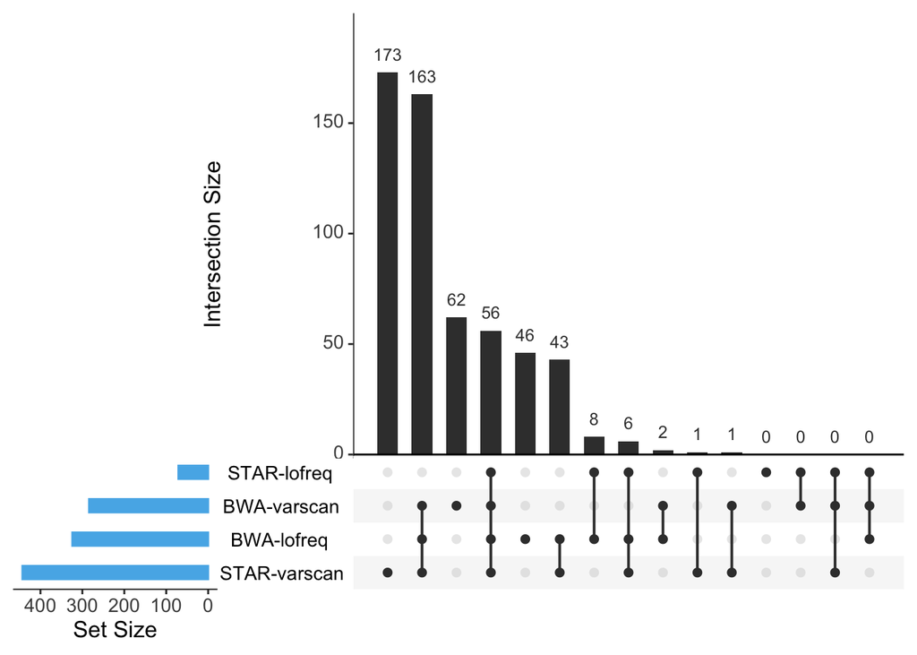

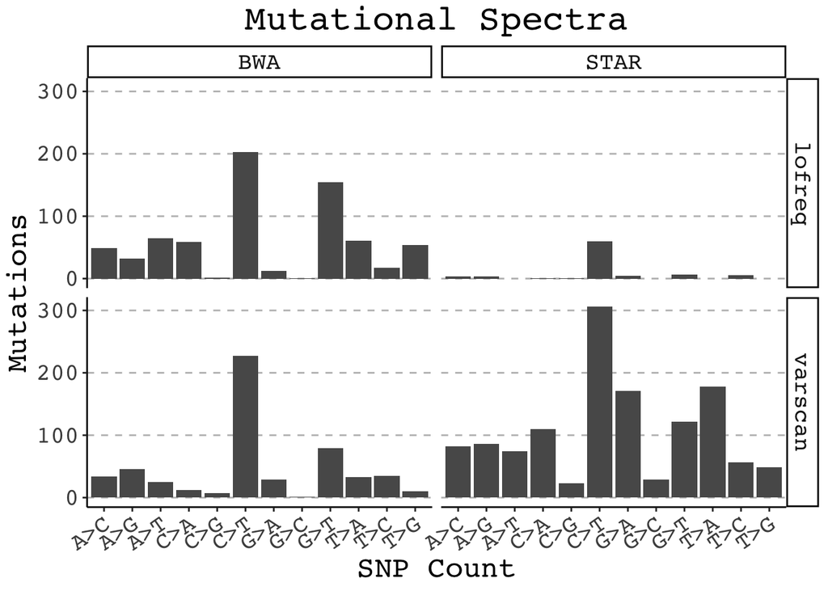

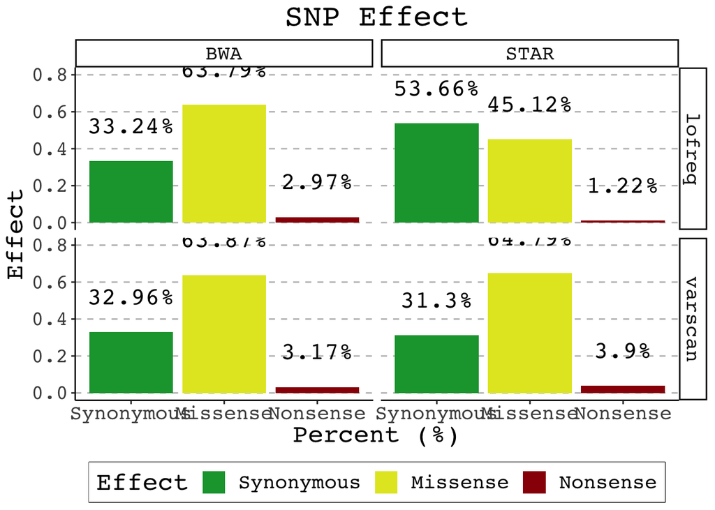

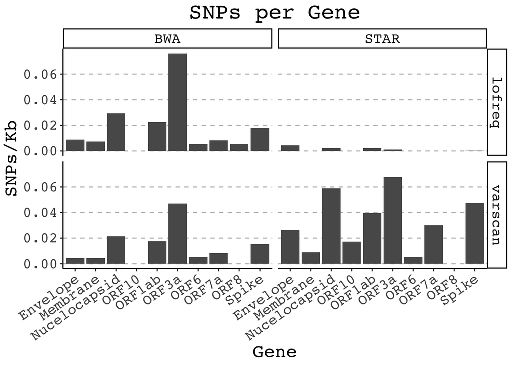

[figure not shown]